## Introduction

Our project explores electricity consumption and electricity prices in different areas of New York City. We start exploring seasonality at the monthly and then weekly levels. We then compare prices vs consumption. The electric grid system in New York state is complex and the prices are not only dependend on consumption in New York City but also on prices from surrounding areas.

## Main analysis (Exploratory Data Analysis)

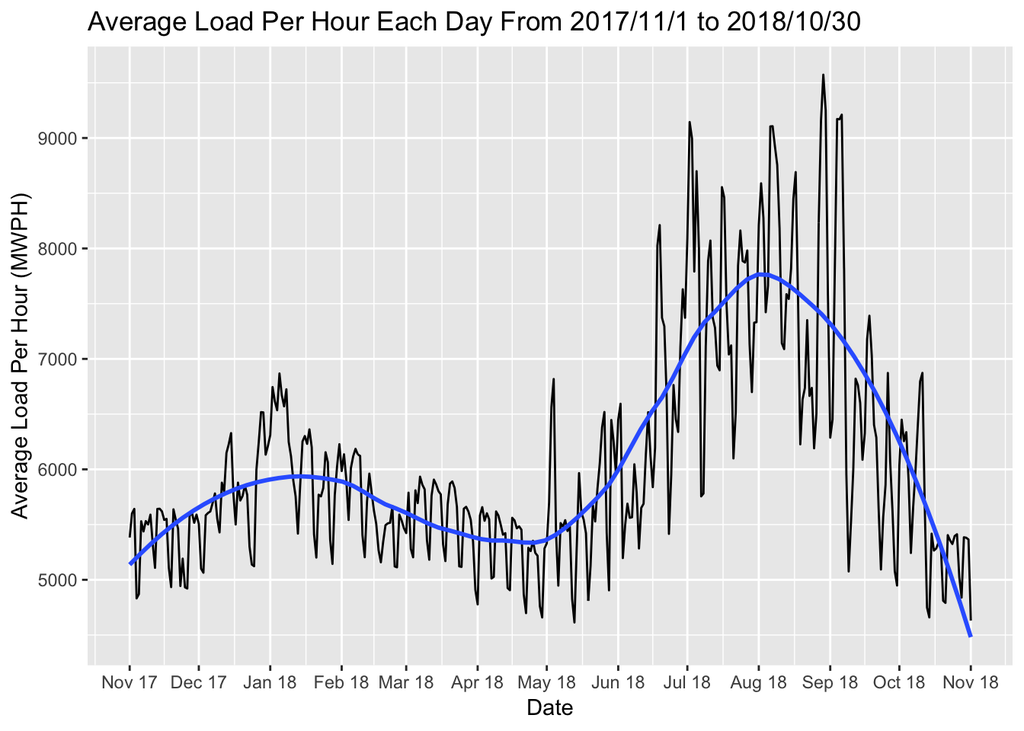

```r
d4 <- ggplot(df_per_hour_day_2018, aes(date, per_day_load)) +
  geom_line() +
  geom_smooth(method = "loess", span = .5, se = FALSE) +
  ggtitle("Average Load Per Hour Each Day From 2017/11/1 to 2018/10/30") +
  xlab("Date") +
  ylab("Average Load Per Hour (MWPH)") +
  scale_x_date(date_breaks = "1 month", date_labels = "%b %y")

d4
```

As we can observe above, there are two peaks of electricity usage throughout a year. We can conclude from the dates of the year that electricity use surged in summer and also high in winter but not as high as summer. There are conspicuous patterns within smaller periods of time for us to explore.

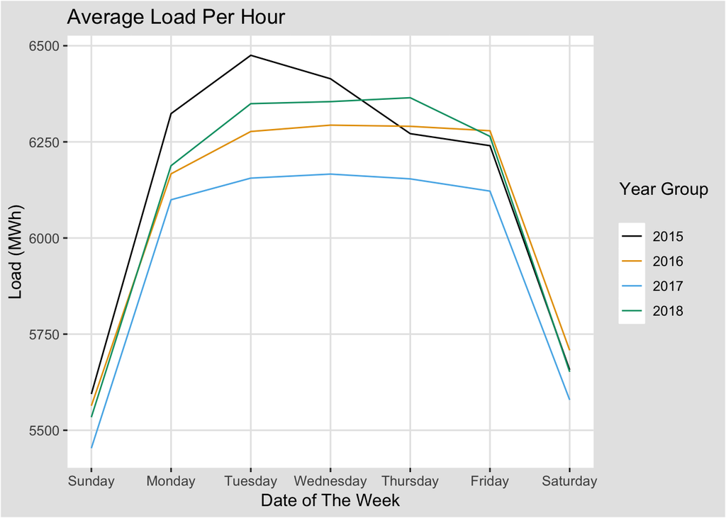

```r
d1_1 <- ggplot(df_per_hour_week, aes(as.numeric(wday), per_dayofweek_load, color=Group)) +
  geom_line() +
  ggtitle("Average Load Per Hour On Each Day Of the Week") +
  scale_x_continuous(name="Date of The Week",
                     breaks=seq(1,7,1),
                     labels=c("Sunday", "Monday", "Tuesday","Wednesday", "Thursday", "Friday","Saturday")) +
  scale_y_continuous(name="Load (MWh)") +
  labs(title = "Average Load Per Hour", color = "Year Group\n") +
  theme_igray() + scale_colour_colorblind()

d1_1
```

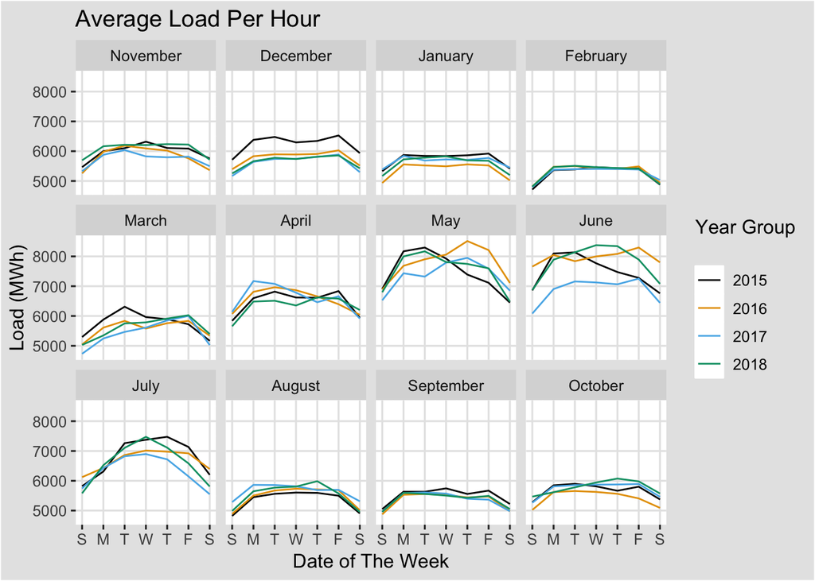

```r
d2_1 <- ggplot(data = df_per_hour_week_month,
             aes(as.numeric(wday), per_dayofweek_month_load, color=Group)) +
  geom_line()+
  facet_wrap(~Month) +
  scale_x_continuous(name="Date of The Week",
                     breaks=seq(1,7,1),
                     labels=c("S", "M", "T", "W", "T", "F", "S")) +
  scale_y_continuous(name="Load (MWh)") +
  labs(title = "Average Load Per Hour", color = "Year Group\n") +
  theme_igray() + scale_colour_colorblind()

d2_1
```

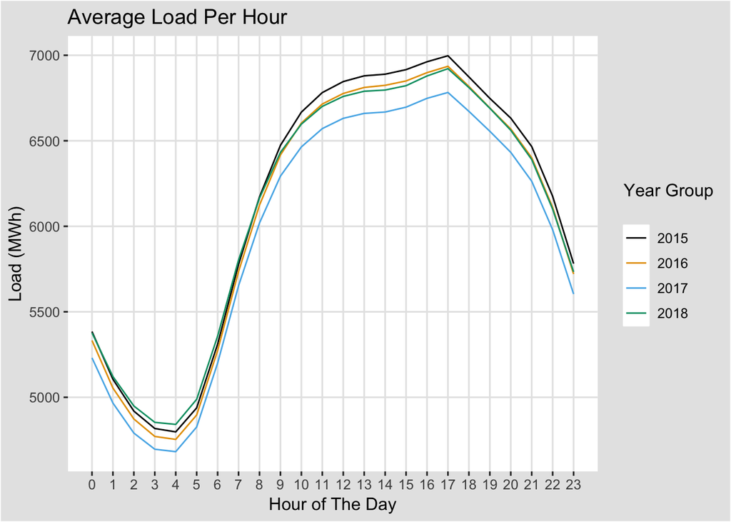

```r
dflh_final <- df_per_hour %>%
  group_by(Group, Hour) %>%
  summarize(hour_average = mean(per_hour_load))

d3 <- ggplot(dflh_final, aes(as.numeric(Hour), hour_average, color=Group)) +
  geom_line()  +
  scale_x_continuous(name="Hour of The Day",
                     minor_breaks = seq(1, 24, 1),
                     breaks=seq(1,24,1),
                     labels=seq(0,23,1)) +
  scale_y_continuous(name="Load (MWh)") +
  labs(title = "Average Load Per Hour", color = "Year Group\n") +
  theme_igray() + scale_colour_colorblind()

d3
```

We can see that there is a clear dip of electricity use after midnight and before working hour each day. Now it is interesting to find out the difference of average load per hour on weekdays and on weekends.

## Executive Summary

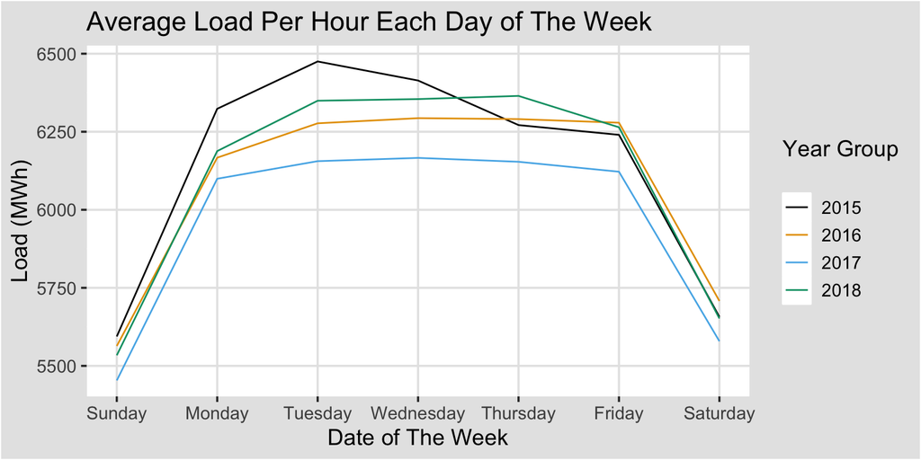

As we conclude from the graph above, there is a clear pattern in the electricity consumptions for different days out of a week, generally for all four years of data that we have measured. The pattern states that during the weekend days, electricity consumption is significantly lowered comparing to the weekdays. And during the weekdays, the amount of electricity used is visibly increased and remained around the same level for every weekday. Now that we observed the trend in electricity consumed among different days of the week regardless the seasonal changes, we have to validate that such trend also exists when we take seasonal differences in consideration as well.

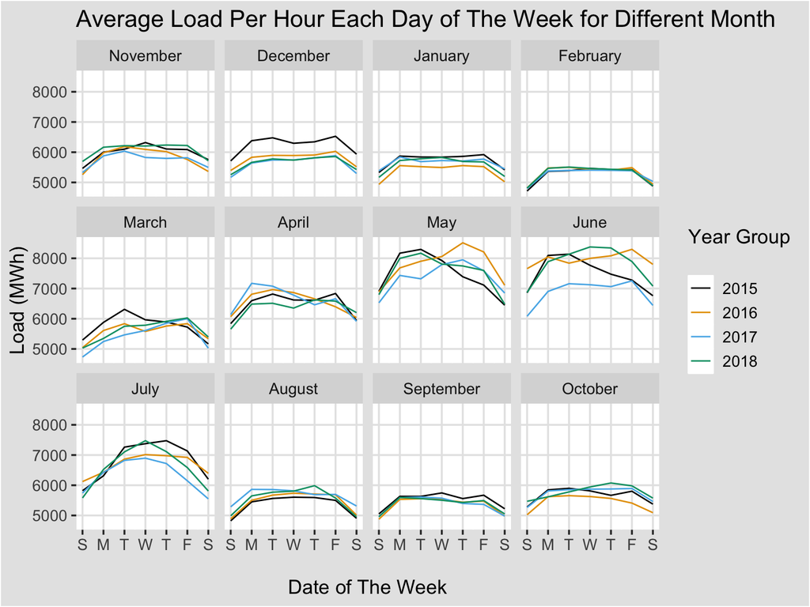